# Arkansas River - Random Forest Testing on GDE Plant Functional Groups

Matthew Lurtz

2025-11-21

## Science Question

The main goal in this manuscript is to test if a given plant functional group (e.g., response variable, NDVI derived from Planet Imagery) has a stronger correlation or dependence with a specific hydroclimatic variable (e.g., covariate, groundwater depth or rainfall, or temperature, etc.). Notably, we will also test if this dependence changes with respect to the temporal resolution (i.e., daily, weekly, and monthly) at which we regress the covariates on the response variable and how the dependence changes during wet and dry years.

# Data and Methods

## Bring in Y and X Datasets (Daily, Populus fremontii)

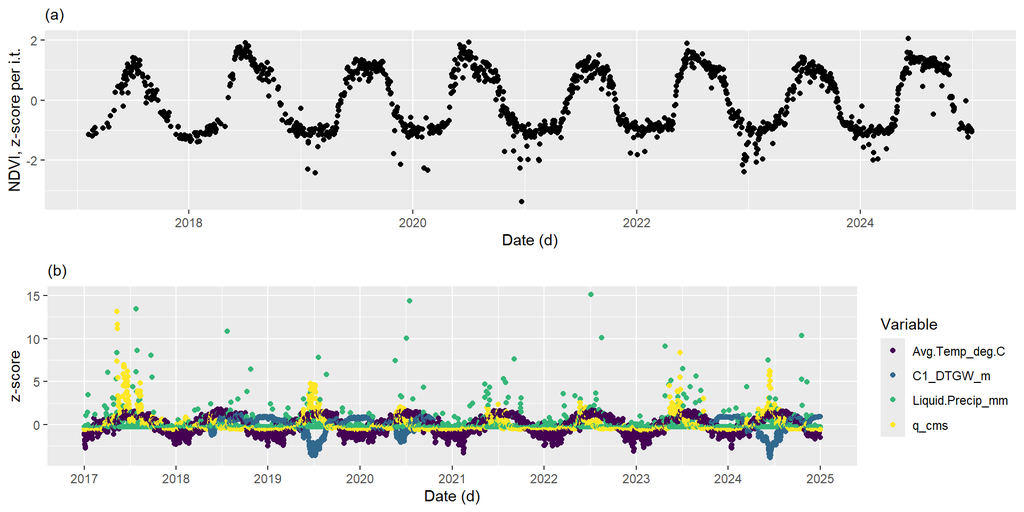

Figure 1. Daily observations of the response variable and select covariates: (a) standardized NDVI, and (b) averages or summations of precipitation, discharge, depth to groundwater (C1), and average atmospheric temperature all plotted on a standarized scale. There are interesting patterns in the peak months of the NDVI time series for years 2018, 2020, and 2022. The time series of the groundwater data is the most sparse of all covariates (5-14-18 to 10-17-20, 10-25-23 to 6-26-25)

## Deseasonalize NDVI using Dynamic Harmonic Regression (Monthly-Weekly-Daily, Populus fremontii)

```
## Running MCMC with 2 parallel chains...
##
## Chain 1 Iteration:    1 / 2000 [  0%]  (Warmup)
## Chain 2 Iteration:    1 / 2000 [  0%]  (Warmup)
## Chain 1 Iteration:  500 / 2000 [ 25%]  (Warmup)
## Chain 2 Iteration:  500 / 2000 [ 25%]  (Warmup)
## Chain 1 Iteration: 1000 / 2000 [ 50%]  (Warmup)
## Chain 1 Iteration: 1001 / 2000 [ 50%]  (Sampling)
## Chain 2 Iteration: 1000 / 2000 [ 50%]  (Warmup)
## Chain 2 Iteration: 1001 / 2000 [ 50%]  (Sampling)
## Chain 1 Iteration: 1500 / 2000 [ 75%]  (Sampling)
## Chain 2 Iteration: 1500 / 2000 [ 75%]  (Sampling)
## Chain 1 Iteration: 2000 / 2000 [100%]  (Sampling)
## Chain 1 finished in 181.1 seconds.
## Chain 2 Iteration: 2000 / 2000 [100%]  (Sampling)
## Chain 2 finished in 183.4 seconds.
##
## Both chains finished successfully.
## Mean chain execution time: 182.3 seconds.
## Total execution time: 183.7 seconds.
```

```
## Running MCMC with 2 parallel chains...
##
## Chain 1 Iteration:    1 / 2000 [  0%]  (Warmup)
## Chain 2 Iteration:    1 / 2000 [  0%]  (Warmup)
## Chain 1 Iteration:  500 / 2000 [ 25%]  (Warmup)
## Chain 2 Iteration:  500 / 2000 [ 25%]  (Warmup)
## Chain 1 Iteration: 1000 / 2000 [ 50%]  (Warmup)
## Chain 1 Iteration: 1001 / 2000 [ 50%]  (Sampling)
## Chain 2 Iteration: 1000 / 2000 [ 50%]  (Warmup)
## Chain 2 Iteration: 1001 / 2000 [ 50%]  (Sampling)
## Chain 1 Iteration: 1500 / 2000 [ 75%]  (Sampling)
## Chain 2 Iteration: 1500 / 2000 [ 75%]  (Sampling)
## Chain 1 Iteration: 2000 / 2000 [100%]  (Sampling)
## Chain 1 finished in 13.9 seconds.
## Chain 2 Iteration: 2000 / 2000 [100%]  (Sampling)
## Chain 2 finished in 14.1 seconds.
##
## Both chains finished successfully.
## Mean chain execution time: 14.0 seconds.
## Total execution time: 14.3 seconds.
```

```
## Running MCMC with 2 parallel chains...
##
## Chain 1 Iteration:    1 / 2000 [  0%]  (Warmup)
## Chain 2 Iteration:    1 / 2000 [  0%]  (Warmup)
## Chain 1 Iteration:  500 / 2000 [ 25%]  (Warmup)
## Chain 2 Iteration:  500 / 2000 [ 25%]  (Warmup)
## Chain 1 Iteration: 1000 / 2000 [ 50%]  (Warmup)
## Chain 2 Iteration: 1000 / 2000 [ 50%]  (Warmup)
## Chain 1 Iteration: 1001 / 2000 [ 50%]  (Sampling)
## Chain 2 Iteration: 1001 / 2000 [ 50%]  (Sampling)
## Chain 1 Iteration: 1500 / 2000 [ 75%]  (Sampling)
## Chain 2 Iteration: 1500 / 2000 [ 75%]  (Sampling)
## Chain 1 Iteration: 2000 / 2000 [100%]  (Sampling)
## Chain 2 Iteration: 2000 / 2000 [100%]  (Sampling)
## Chain 1 finished in 2.9 seconds.
## Chain 2 finished in 2.9 seconds.
##
## Both chains finished successfully.
## Mean chain execution time: 2.9 seconds.
## Total execution time: 3.1 seconds.
```

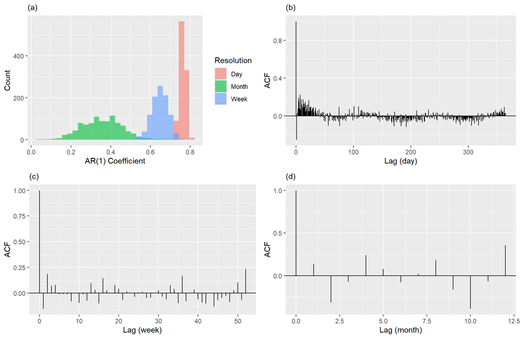

Figure 2. Output from deseasonalizing the response data using a Bayesian implementation of the dynamic harmonic regression model (i.e., one harmonic plus autoregressive component) at monthly, weekly and daily time resolutions: (a) posterior distribution of the AR(1) correlation coefficient at the daily, weekly, and monthly resolution for the phreatophyte PFG, and (b,c,d) an ACF plot of the daily, weekly, and monthly deseasonlized NDVI time series with lag up to 1-year.

### Covariates

Table. A tabular list of covariates tested in the Random Forest algorithm using the Ranger package. All covariates are standardized at the daily temporal resolution.

Covariate

Form

Source

Lagged

Groundwater Depth (m)

15min Avg. To Daily

Well C1

Day, Weekly Avg., Monthly Avg.

Groundwater Temp. (Cels.)

15min Avg. To Daily

Well C1

Day, Weekly Avg., Monthly Avg.

Discharge (cms)

Daily Avg.

ARKROCCO

Day, Weekly Avg., Monthly Avg.

Gage Height (m)

Daily Avg.

ARKROCCO

Day, Weekly Avg., Monthly Avg.

Surf. Water Temp. (Cels.)

Daily Avg.

ARKROCCO

Day, Weekly Avg., Monthly Avg.

Avg. Atmos. Temp. (Cels.)

Daily Avg.

RFD01

Day, Weekly Avg., Monthly Avg.

RH (percent)

Daily Avg.

RFD01

Day, Weekly Avg., Monthly Avg.

Vapor Press. (kPa)

Daily Avg.

RFD01

Day, Weekly Avg., Monthly Avg.

Precip. (mm)

Daily Sum

RFD01

Day, Weekly Avg., Monthly Avg.

Wind Run (km)

Daily Avg.

RFD01

Day, Weekly Avg., Monthly Avg.

Gust Speed (m.s)

Daily Avg.

RFD01

Day, Weekly Avg., Monthly Avg.

Solar Rad. (W.m.2)

Daily Avg.

RFD01

Day, Weekly Avg., Monthly Avg.

ASCE ETr (mm)

Daily Avg.

RFD01

Day, Weekly Avg., Monthly Avg.

NDVI

Rep. and Obs. Daily Avg.

Planet

Day, Weekly Avg., Monthly Avg.

Atmos. Temp. and GW Temp. Diff.

Daily Avg.

Well C1 and RFD01

Day, Weekly Avg., Monthly Avg.

3-mo Lag

Table. Latitude and longitude location for the 12 groundwater wells located near Rocky Ford, Colorado.

| Well_ID | Lon | Lat |
| --- | --- | --- |
| A1 | -103.6872 | 38.05882 |
| A2 | -103.6851 | 38.05830 |
| A3 | -103.6858 | 38.05564 |
| A4 | -103.6846 | 38.05482 |
| B1 | -103.6834 | 38.04795 |
| B2 | -103.6835 | 38.04926 |
| B3 | -103.6830 | 38.05027 |
| B4 | -103.6830 | 38.05200 |
| C1 | -103.6749 | 38.05061 |
| C2 | -103.6725 | 38.05224 |
| C3 | -103.6720 | 38.05291 |
| C4 | -103.6711 | 38.05374 |

### Wet and Dry Years, Ranked

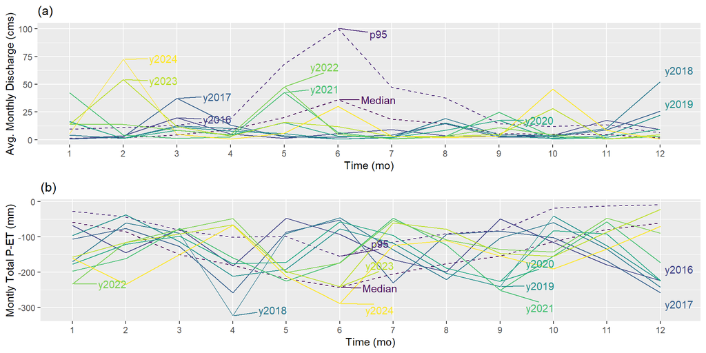

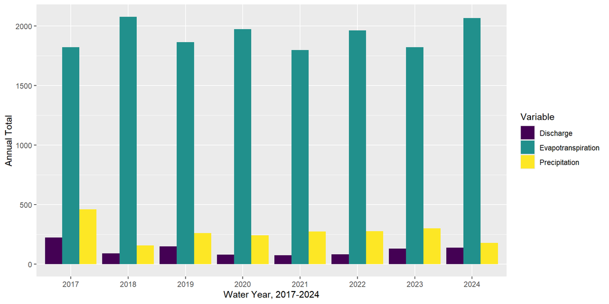

Figure 4. Water year totals for precipitation, evapotranspiration and discharge for the period of interest.

# Results

## Random Forest (Entire Dataset)

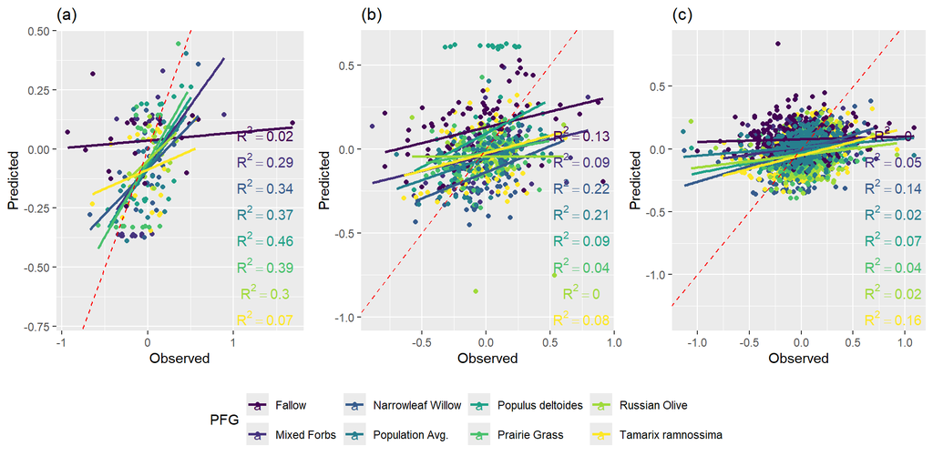

Figure 4. OOS model validation, using 25 percent of original dataset, for all PFGs at monthly, weekly, and daily temporal resolutions with a 1:1 (red-dashed) line plot and a regression (color by PFG) line to highlight predictive accuracy and bias of the witheld (i.e., testing) dataset: a) monthly, b) weekly, and c) daily.

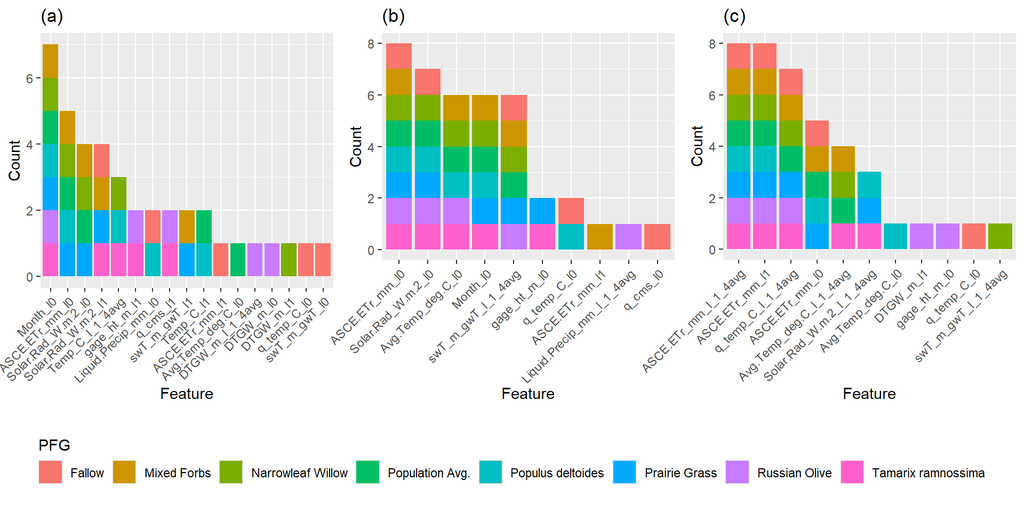

Figure 5. Top 5 features of importance based on impurity: a) monthly, b) weekly, and c) daily. This Impurity is based on the average total reduction of the loss function for a given feature across all trees. Reference: (https://bradleyboehmke.github.io/HOML/random-forest.html).

## Random Forest (5-14-18 to 10-17-20, 10-25-23 to 6-26-25))

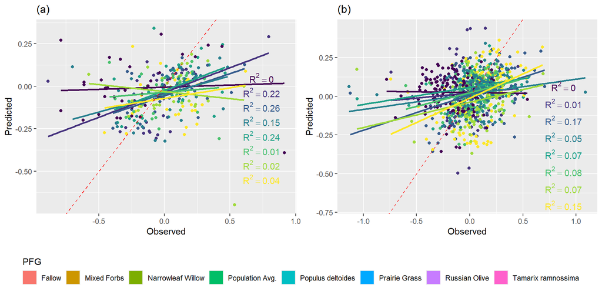

Figure 6. OOS model validation, using 25 percent of original dataset, for all PFGs at weekly and daily temporal resolutions with a 1:1 (red-dashed) line plot and a regression (color by PFG) line to highlight predictive accuracy and bias of the witheld (i.e., testing) dataset: a) weekly and b) daily.

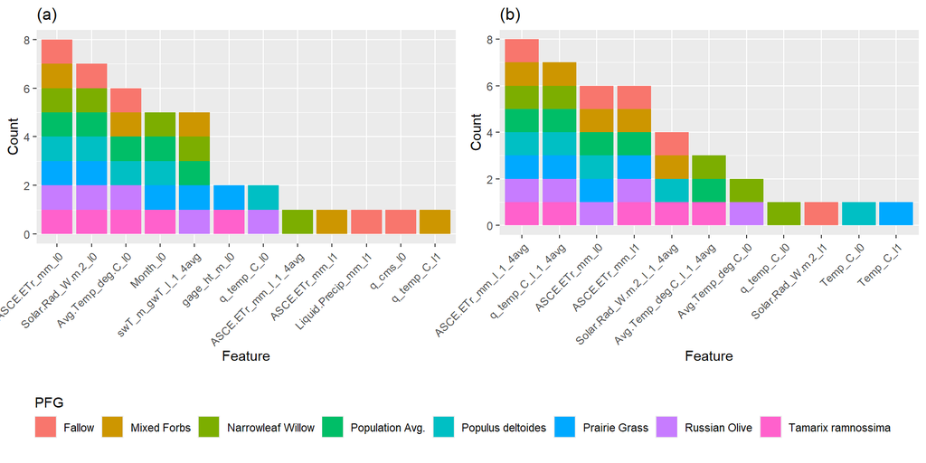

Figure 7. Top 5 features of importance based on impurity: a) weekly and b) daily. This Impurity is based on the average total reduction of the loss function for a given feature across all trees. Reference: (https://bradleyboehmke.github.io/HOML/random-forest.html).

## Random Forest (Wet and Dry Years Only)

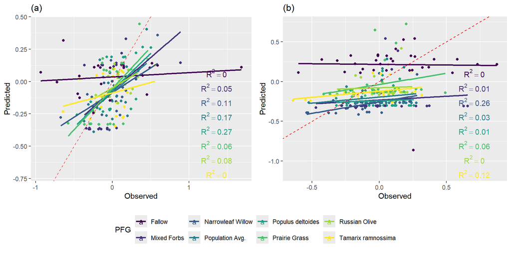

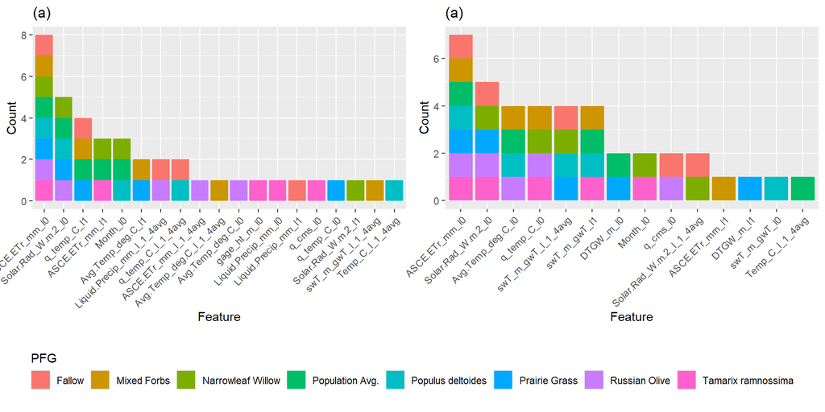

Figure 9. Top 5 features of importance based on impurity: a) weekly-dry and b) weekly-wet. This Impurity is based on the average total reduction of the loss function for a given feature across all trees. Reference: (https://bradleyboehmke.github.io/HOML/random-forest.html).

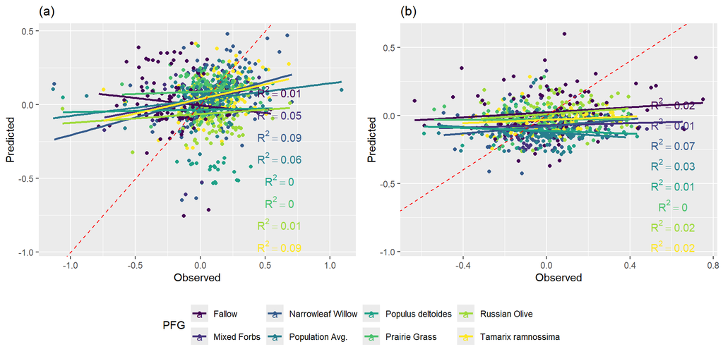

Figure 10. OOS model validation, using 25 percent of original dataset, for all PFGs at daily temporal resolutions with a 1:1 (red-dashed) line plot and a regression (color by PFG) line to highlight predictive accuracy and bias of the witheld (i.e., testing) dataset: a) daily-dry and b) daily-wet.

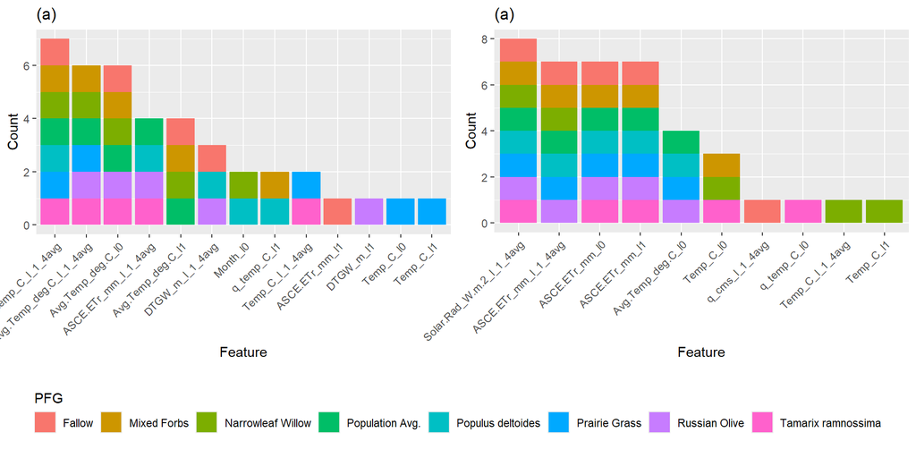

Figure 11. Top 5 features of importance based on impurity: a) daily-dry and b) daily-wet. This Impurity is based on the average total reduction of the loss function for a given feature across all trees. Reference: (https://bradleyboehmke.github.io/HOML/random-forest.html).